###### Before run this notebook, please install all packages based on requirement.txt

###### Please copy 2012_to_2014_institutions_data.csv and 2012_to_2014_loans_data.csv to data/ fold.

```python
import pandas as pd
import numpy as np
import operator
import datetime
import seaborn as sns
import matplotlib.pyplot as plt
import matplotlib as mpl
from bokeh.charts import Donut, show, output_notebook
from bokeh.layouts import row
from bokeh.plotting import figure
from sklearn.preprocessing import StandardScaler
from sklearn.decomposition import PCA
from sklearn.cluster import KMeans
from sklearn import svm
from sklearn.model_selection import train_test_split
from sklearn.ensemble import RandomForestClassifier
output_notebook()
%matplotlib inline
```

# Step 1: Data Munging

```python
# input the class for data munging
from src.data_munging import data_munging
```

```python
# init the data munging class
dm = data_munging()
# run the hmda_init() function
cache_df_part = dm.hmda_init()
```

```
Main part datasets have been merged successfully. 27 columns and 1321158 rows
```

```python
cache_df = dm.hmda_init(True)
```

```
Full size datasets have been merged successfully. 35 columns and 1321158 rows
```

```python
cache_df.dtypes
```

```
Agency_Code                        object
Applicant_Income_000               object
As_of_Year                          int64
Census_Tract_Number                object
County_Code                        object
FFIEC_Median_Family_Income         object
Loan_Amount_000                     int64
MSA_MD                             object
Number_of_Owner_Occupied_Units     object
Respondent_ID                      object
Sequence_Number                     int64
State_Code                           int8
Tract_to_MSA_MD_Income_Pct         object
MSA_MD_Description                 object
Loan_Purpose_Description           object
Agency_Code_Description            object
Lien_Status_Description            object
Loan_Type_Description              object
State                              object
County_Name                        object
Conforming_Limit_000              float64
Conventional_Status                object
Conforming_Status                  object
Conventional_Conforming_Flag       object
Respondent_Name_TS                 object
Respondent_City_TS                 object
Respondent_State_TS                object
Respondent_ZIP_Code                object
Parent_Name_TS                     object
Parent_City_TS                     object
Parent_State_TS                    object
Parent_ZIP_Code                    object
Assets_000_Panel                    int64
Loans_Category                     object
Loan_Merge_Category                object
dtype: object
```

```python
# 'DC', 'DE', 'MD', 'VA', 'WV'
dm.hmda_to_json(cache_df, ['DC', 'DE'], 'Y')
```

```
Dataset has been download at data/record_20180220T055851.json using states: ['DC', 'DE'] and conventional_conforming: Y
```

# Step 2: Quality Check

### Based on the requirement, we will check the Loan_amount_000 and Respondent_Name at first.

### Loan_amount_000 is Continuous Data. Respondent_Name is Categorical Data.

```python
# Loan_Amount_000 simple descriptive statistics
cache_df['Loan_Amount_000'].describe()
```

```
count    1.321158e+06
mean     2.902331e+02
std      9.657792e+02
min      1.000000e+00
25%      1.530000e+02
50%      2.350000e+02
75%      3.470000e+02
max      9.962500e+04
Name: Loan_Amount_000, dtype: float64
```

###### Based on the descriptive statistics, we can see that the amount between min and max has a big gap. And std is a big number. Loan_Amount_000 should has outlier.

```python
# check the None
def null_count(column):
    column_null = pd.isnull(column)
    null = column[column_null]
    return len(null)
print(cache_df.apply(null_count)[['Loan_Amount_000']])
```

```
Loan_Amount_000    0
dtype: int64
```

###### For each column, we will check the None at first. Based on the above check, we don't find the None for the Loan_Amount_000.

```python
# check outlier
def check_outlier(col):
    c = 0.67448975019608171
    thresh = 3.5
    median = np.median(col)
    diff = np.abs(col - median)
    mad = np.median(diff)
    z_score = c * diff / mad
    return list(np.where(z_score > thresh)[0])

loans_check_outlier_list = ['Loan_Amount_000']
total_cache_df = len(cache_df)
outlier_index_hashmap = {}

for col in loans_check_outlier_list:
    outlier_index_hashmap[col] = check_outlier(cache_df[col])
for key in outlier_index_hashmap:
    print('({0}: {1}) - (Total: {2}) - (Percentage: {3}%)'
          .format(key,
                  len(outlier_index_hashmap[key]),
                  total_cache_df,
                  np.round((len(outlier_index_hashmap[key]) / total_cache_df) * 100, 2)))
```

```
(Loan_Amount_000: 27472) - (Total: 1321158) - (Percentage: 2.08%)
```

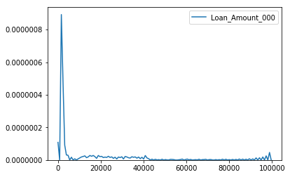

```python
sns.kdeplot(cache_df['Loan_Amount_000'])
```

###### Based on the number and diagram, there are 2.08% data points which are kind of outliers. We need to filter them out or category them into different categories.

###### Also Application_Income_000 has directly impact to Loan_Amount_000, that means lower Apllication_Income_000 cannot have higher Loan_Amount_000. I will deal with Applicant_Income_000 at first.

###### Additional column which need to be checked: Applicant_Income_000

```python
# replace NA with np.nan
cache_df['Applicant_Income_000'] = cache_df['Applicant_Income_000'].replace(r'^NA\s+', np.nan, regex=True)
# convert Applicant_Income_000 to numeric.
cache_df['Applicant_Income_000'] = pd.to_numeric(cache_df['Applicant_Income_000'], errors="coerce")
```

```python
# show missing value
print(cache_df.apply(null_count)[['Applicant_Income_000']])
```

```
Applicant_Income_000    117853
dtype: int64
```

###### There are 117853 missing value for the income column, becuase it is a big number, we use mean to fill the missing value.

```python
# filled mean to missing value
cache_df[['Applicant_Income_000']] = cache_df[['Applicant_Income_000']].fillna(cache_df[['Applicant_Income_000']].mean())
```

###### I will list all application whose loan_amount is 20 times than applicant_income to remove them.

```python
to_be_remove_app_loan = cache_df[(cache_df['Applicant_Income_000'] * 20 < cache_df['Loan_Amount_000'])]
print(to_be_remove_app_loan[['Applicant_Income_000', 'Loan_Amount_000']].head(5))
print(to_be_remove_app_loan[['Applicant_Income_000', 'Loan_Amount_000']].tail(5))
print('the length of to_be_remove_app_loan: {}'.format(len(to_be_remove_app_loan)))
```

```
       Applicant_Income_000  Loan_Amount_000
28243                  17.0              695
37200                  10.0              279
37967                  12.0              283
41928                   6.0              183
44350                   4.0              270
         Applicant_Income_000  Loan_Amount_000
1321153                  53.0            16036
1321154                 106.0            31920
1321155                  51.0            15471
1321156                  49.0            14752
1321157                  45.0            13719
the length of to_be_remove_app_loan: 1711
```

```python
cache_df = cache_df[(cache_df['Applicant_Income_000'] * 20 >= cache_df['Loan_Amount_000'])]
cache_df.shape
```

```
(1319447, 35)
```

###### After checking the distribuation of loan categories, expect for 'unbelievable', all others are all resonable not outlier.

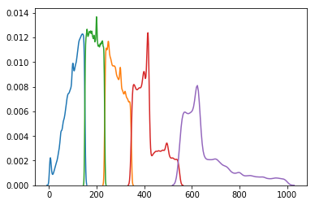

```python
sns.kdeplot(cache_df[cache_df['Loans_Category']=='low']['Loan_Amount_000'], legend=False)
sns.kdeplot(cache_df[cache_df['Loans_Category']=='high']['Loan_Amount_000'], legend=False)
sns.kdeplot(cache_df[cache_df['Loans_Category']=='medium']['Loan_Amount_000'], legend=False)
sns.kdeplot(cache_df[cache_df['Loans_Category']=='very high']['Loan_Amount_000'], legend=False)
sns.kdeplot(cache_df[cache_df['Loans_Category']=='extremely high']['Loan_Amount_000'], legend=False)
```

###### After checking the Respondent_Name_TS and Respondent_Name_TS_Plus_ID, we can find that some Respondent_Name_TS is the same but their Respondent_ID are different becuase there are at different location. We add more one column for the Respondent_Name, and then we can have unique column for the respondent name.

```python
# Respondent_Name simple descriptive statistics
cache_df['Respondent_Name_TS'].describe()
```

```
count                  1319447
unique                    1601
top       WELLS FARGO BANK, NA
freq                    137050
Name: Respondent_Name_TS, dtype: object
```

```python
cache_df['Respondent_Name_TS_Plus_ID'] = cache_df['Respondent_ID'] + '_'+ cache_df['Respondent_Name_TS']
```

```python
cache_df['Respondent_Name_TS_Plus_ID'].describe()
```

```
count                             1319447
unique                               1642
top       0000451965_WELLS FARGO BANK, NA
freq                               137050
Name: Respondent_Name_TS_Plus_ID, dtype: object
```

###### Additional columns which need to be checked: Parent data.

###### Because Respondent_Name has more than 1600 unique name, we need to have small range, so parent data can help use.

```python
respondent_parent = {
    'Parent_Name_TS': 'Respondent_Name_TS',
    'Parent_City_TS': 'Respondent_City_TS',
    'Parent_State_TS': 'Respondent_State_TS',
    'Parent_ZIP_Code': 'Respondent_ZIP_Code'
}
```

```python
print(cache_df.apply(null_count)[[key for key in respondent_parent]])
```

```
Parent_Name_TS     664244
Parent_City_TS     664244
Parent_State_TS    664102
Parent_ZIP_Code    663679
dtype: int64
```

```python
for parent_col in respondent_parent:
    cache_df[parent_col].fillna(cache_df[respondent_parent[parent_col]], inplace=True)
```

```python
print(cache_df.apply(null_count)[[key for key in respondent_parent]])
```

```
Parent_Name_TS     0
Parent_City_TS     0
Parent_State_TS    0
Parent_ZIP_Code    0
dtype: int64
```

#### Based on above quality assessment, we create a class to do the quality monitoring. columns which need to be checked: Parent data.

```python
dm = data_munging()
test = dm.hmda_init(True)
```

```
Full size datasets have been merged successfully. 35 columns and 1321158 rows
```

```python
from src.quality_check import quality_check
qc = quality_check(test)
qc.check_duplicate()
qc.check_missing_value()
qc.check_outlier()
```

```python
qc.create_report()
```

# Step 3: Data Analysis

## 3.1. Time Seires Pattern

#### Step 3.1.1 Overview

```python
# group by year and state
year_all_groupby = cache_df.groupby(['As_of_Year', 'State',], as_index=False).agg(
    {
        'Loan_Amount_000': [np.sum, np.mean, np.size],
        'Applicant_Income_000': [np.sum, np.median],
    }
)
year_all_groupby.columns = ['_'.join(col) if col[1] else col[0] for col in year_all_groupby.columns]
```

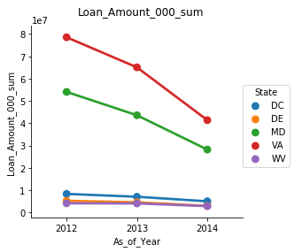

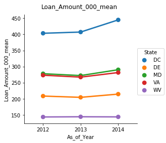

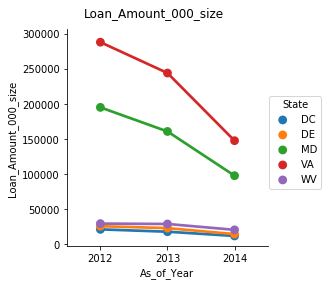

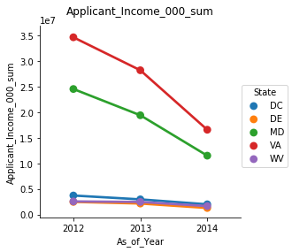

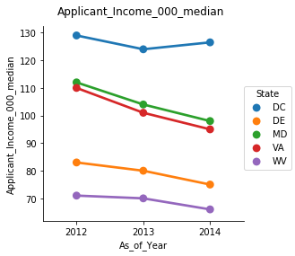

```python
cols = ['Loan_Amount_000_sum', 'Loan_Amount_000_mean', 'Loan_Amount_000_size', 'Applicant_Income_000_sum', 'Applicant_Income_000_median']

for col in cols:
    g = sns.factorplot(x="As_of_Year", y=col, hue="State", data=year_all_groupby)
    plt.subplots_adjust(top=0.9)
    g.fig.suptitle(col)
```

###### Step 3.1.1 conculation: We can see that number of application, sum of loan, and median of income decrease among 5 states over the years. So we need to find out why this will happen.

#### Step 3.1.2 Loan Purpose Description: Purchase and Refinance

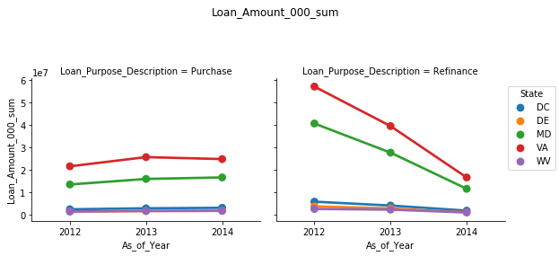

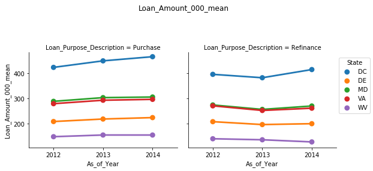

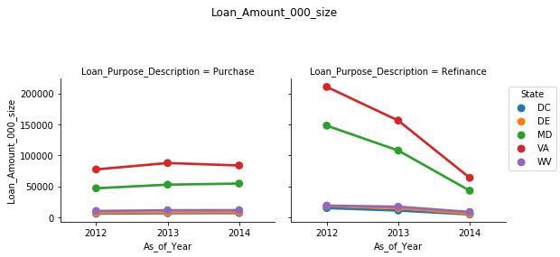

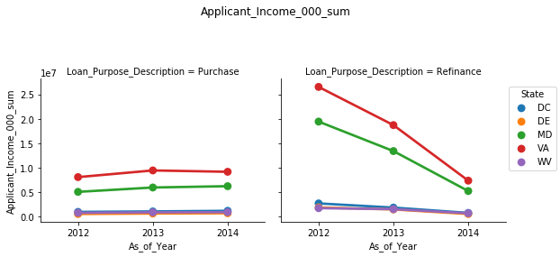

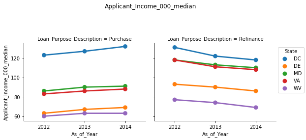

```python
year_loan_purpose_groupby = cache_df.groupby(['As_of_Year', 'State', 'Loan_Purpose_Description'], as_index=False).agg(
    {
        'Loan_Amount_000': [np.sum, np.mean, np.size],
        'Applicant_Income_000': [np.sum, np.median],
    }
)
year_loan_purpose_groupby.columns = ['_'.join(col) if col[1] else col[0] for col in year_loan_purpose_groupby.columns]
cols = ['Loan_Amount_000_sum', 'Loan_Amount_000_mean', 'Loan_Amount_000_size', 'Applicant_Income_000_sum', 'Applicant_Income_000_median']
for col in cols:
    g = sns.factorplot(x="As_of_Year", y=col, hue="State", col='Loan_Purpose_Description', data=year_loan_purpose_groupby)
    plt.subplots_adjust(top=0.7)
    g.fig.suptitle(col)
```

#### Step 3.1.3 Loan Merge Category based on purchase description: normal, very high, extremely high, and unbeliveable

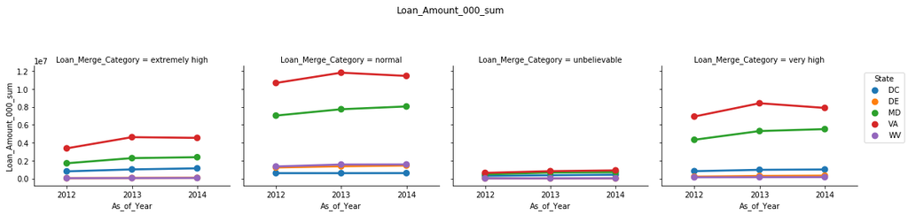

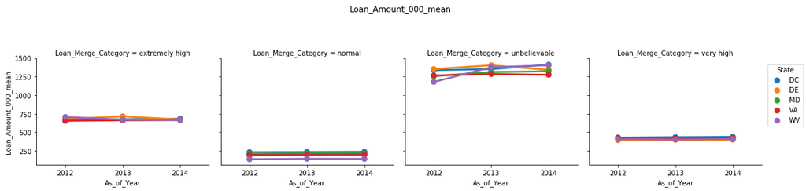

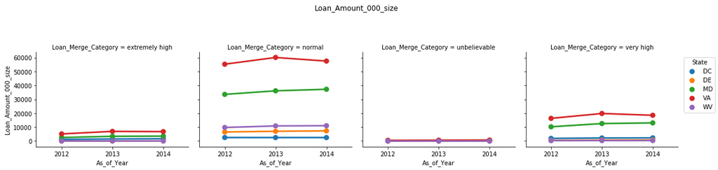

```python
year_loan_merge_category_groupby = cache_df[cache_df['Loan_Purpose_Description'] == 'Purchase'].groupby(['As_of_Year', 'State', 'Loan_Merge_Category'], as_index=False).agg(
    {
        'Loan_Amount_000': [np.sum, np.mean, np.size]
    }
)
year_loan_merge_category_groupby.columns = ['_'.join(col) if col[1] else col[0] for col in year_loan_merge_category_groupby.columns]
cols = ['Loan_Amount_000_sum', 'Loan_Amount_000_mean', 'Loan_Amount_000_size']

for col in cols:
    g = sns.factorplot(x="As_of_Year", y=col, hue="State", col='Loan_Merge_Category', data=year_loan_merge_category_groupby)
    plt.subplots_adjust(top=0.7)
    g.fig.suptitle(col)
```

###### Step 3.1.3 conculation: for different loan amount based on purchase, they don't have very different change. But for the amount of loan, the normal category has a large amount.

### Step 3.1 conculation: for the total, we can find that number of application, sum of loan, and median of income decrease; for the purchase propose, those three feature increase or the same as previous.

## Step 3.2 Geolocation

### Step 3.2.1 County with Purchase Purpose

```
Text(0.5,0.98,'all county, purchase purpose')
```

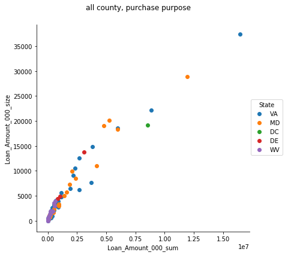

```python
county_purpose_groupby = cache_df[cache_df['Loan_Purpose_Description'] == 'Purchase'].groupby(['County_Name', 'State'], as_index=False).agg({'Loan_Amount_000': [np.sum, np.size, np.median]})
county_purpose_groupby.columns = ['_'.join(col) if col[1] else col[0] for col in county_purpose_groupby.columns]

county_purpose_groupby.sort_values(['Loan_Amount_000_sum','Loan_Amount_000_size'], ascending=False, inplace=True)

g = sns.FacetGrid(county_purpose_groupby, hue="State", size=6)
g.map(plt.scatter, "Loan_Amount_000_sum", "Loan_Amount_000_size")
g.add_legend()
plt.subplots_adjust(top=0.9)
g.fig.suptitle('all county, purchase purpose')
```

```python
top_20_county = county_purpose_groupby.head(20)['County_Name']
```

```python
county_purpose_groupby.head(20).groupby('State').count()['County_Name']
```

```
State
DC     1
DE     1
MD     8
VA    10
Name: County_Name, dtype: int64
```

###### Step 3.2.1 conculation: the counties in VA and MD have most amount and size of loan. In the top 20, there are 18 counties in VA and MD

### Step 3.2.2 State with Purchase Purpose

```python
loan_category_groupby = cache_df[cache_df['Loan_Purpose_Description'] == 'Purchase'].groupby(['Loan_Merge_Category', 'State'], as_index=False).agg({'Loan_Amount_000': [np.sum, np.size]})
loan_category_groupby.columns = ['_'.join(col) if col[1] else col[0] for col in loan_category_groupby.columns]
```

```python
five_colors = ['#8d8482','#d0ac2f','#a0c1e3','#f96465','#f4ebdc']
d = Donut(loan_category_groupby, label=['State'], values='Loan_Amount_000_sum',
          text_font_size='8pt', hover_text='Loan_Amount_000_sum', color=five_colors)
show(d)
```

[interactive chart not shown]

###### Step 3.2.2 conculation: VA and MD Purchase Purpose with have the largest amount loan.

### Step 3.2 conculation: The counties in the VA and MD have larger loan of amount.

## Step 3.3: Conventional/Conforming analysis

### Step 3.3.1 Overview.

```python
loan_category_groupby = cache_df.groupby(['Conventional_Conforming_Flag', 'State', 'As_of_Year'], as_index=False).agg({'Loan_Amount_000': [np.sum, np.size]})
loan_category_groupby.columns = ['_'.join(col) if col[1] else col[0] for col in loan_category_groupby.columns]
```

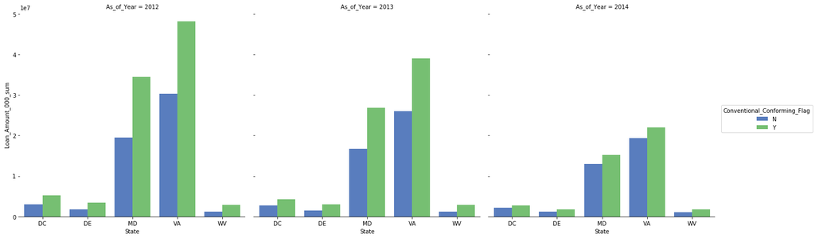

```python
g = sns.factorplot(x='State', y="Loan_Amount_000_sum", hue="Conventional_Conforming_Flag", data=loan_category_groupby,
                   size=6, kind="bar", palette="muted", col='As_of_Year')
g.despine(left=True)
g.set_ylabels("Loan_Amount_000_sum")
```

###### Step 3.3.1 conculation: The applications which have conventional and conforming are more than don't have for overall.

### Step 3.3.2 Within MD and VA, using Purchase Purpose

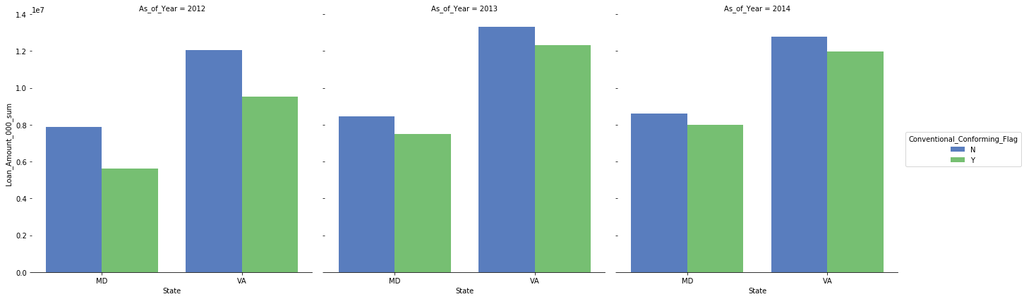

```python
loan_category_groupby = cache_df[(cache_df['Loan_Purpose_Description'] == 'Purchase') & ((cache_df['State'] == 'VA') | (cache_df['State'] == 'MD'))].groupby(['Conventional_Conforming_Flag', 'State', 'As_of_Year'], as_index=False).agg({'Loan_Amount_000': [np.sum, np.size]})
loan_category_groupby.columns = ['_'.join(col) if col[1] else col[0] for col in loan_category_groupby.columns]

g = sns.factorplot(x='State', y="Loan_Amount_000_sum", hue="Conventional_Conforming_Flag", data=loan_category_groupby,
                   size=6, kind="bar", palette="muted", col='As_of_Year')
g.despine(left=True)
g.set_ylabels("Loan_Amount_000_sum")
```

###### Step 3.3.2 conculation: The applications which have conventional and conforming within MD and VA, using Purchase Purpose are a few less than don't have for overall.

### Step 3.3.2 conculation: Prefer to do the conventional and conforming, even it is just a few less than don't have but have less risk also.

## Step 3.4: competitor analysis

### Step 3.4.1 Overview

```python
loan_parent_groupby = cache_df.groupby(['Parent_Name_TS'], as_index=False).agg({'Loan_Amount_000': [np.sum, np.size]})
loan_parent_groupby.columns = ['_'.join(col) if col[1] else col[0] for col in loan_parent_groupby.columns]
loan_parent_groupby.sort_values(['Loan_Amount_000_sum','Loan_Amount_000_size'], ascending=False, inplace=True)
loan_parent_groupby['per_for_sum'] = (loan_parent_groupby['Loan_Amount_000_sum'] / sum(loan_parent_groupby['Loan_Amount_000_sum'])) * 100
loan_parent_groupby_more_than_2 = loan_parent_groupby[loan_parent_groupby['per_for_sum'] > 2]
viz_loan_parent_groupby_more_than_2 = loan_parent_groupby_more_than_2[['Parent_Name_TS', 'per_for_sum']]
sum(viz_loan_parent_groupby_more_than_2['per_for_sum'])
others = pd.DataFrame([['OTHERS', 100 - sum(viz_loan_parent_groupby_more_than_2['per_for_sum'])]], columns=['Parent_Name_TS', 'per_for_sum'])
# others
viz_loan_parent_groupby_more_than_2 = viz_loan_parent_groupby_more_than_2.append(others)
viz_loan_parent_groupby_more_than_2
```

|  | Parent_Name_TS | per_for_sum |
| --- | --- | --- |
| 1629 | WELLS FARGO & CO | 10.278838 |
| 1264 | QUICKEN LOANS | 4.679031 |
| 150 | BANK OF AMERICA CORPORATION | 3.548853 |
| 1079 | NFCU | 2.796300 |
| 860 | JPMORGAN CHASE BANK, NA | 2.779116 |
| 192 | BB&T CORPORATION | 2.711451 |
| 1422 | SUNTRUST BANK, INC | 2.227444 |
| 588 | FIRST HOME MORTGAGE | 2.021935 |
| 0 | OTHERS | 68.957032 |

```python
d = Donut(viz_loan_parent_groupby_more_than_2, label=['Parent_Name_TS'], values='per_for_sum',
          text_font_size='8pt', hover_text='per_for_sum')
show(d)
```

[interactive chart not shown]

###### Step 3.4.1 conculation: there are just 31% market under 8 compaies which market share is bigger than 2% .

### Step 3.4.2 Purpose: Purchase

```python
loan_parent_purpose_groupby = cache_df[cache_df['Loan_Purpose_Description'] == 'Purchase'].groupby(['Parent_Name_TS'], as_index=False).agg({'Loan_Amount_000': [np.sum, np.size]})
loan_parent_purpose_groupby.columns = ['_'.join(col) if col[1] else col[0] for col in loan_parent_purpose_groupby.columns]
loan_parent_purpose_groupby.sort_values(['Loan_Amount_000_sum','Loan_Amount_000_size'], ascending=False, inplace=True)
loan_parent_purpose_groupby['per_for_sum'] = (loan_parent_purpose_groupby['Loan_Amount_000_sum'] / sum(loan_parent_purpose_groupby['Loan_Amount_000_sum'])) * 100
loan_parent_purpose_groupby_more_than_2 = loan_parent_purpose_groupby[loan_parent_purpose_groupby['per_for_sum'] > 2]
viz_loan_parent_purpose_groupby_more_than_2 = loan_parent_purpose_groupby_more_than_2[['Parent_Name_TS', 'per_for_sum']]
others_purpose = pd.DataFrame([['OTHERS', 100 - sum(viz_loan_parent_purpose_groupby_more_than_2['per_for_sum'])]], columns=['Parent_Name_TS', 'per_for_sum'])
# others
viz_loan_parent_purpose_groupby_more_than_2 = viz_loan_parent_purpose_groupby_more_than_2.append(others_purpose)
viz_loan_parent_purpose_groupby_more_than_2

d = Donut(viz_loan_parent_purpose_groupby_more_than_2, label=['Parent_Name_TS'], values='per_for_sum',
          text_font_size='8pt', hover_text='per_for_sum')
show(d)
```

[interactive chart not shown]

###### Step 3.4.2 conculation: there are just 27% market which is under 8 compaies for purchase purpose.

### Step 3.4 conculation: around 70% market share for loan is under companies whose are less than 2% market share.

# Step 4: Clusters and Classification

```python
# Because we will use others' columns, we clean the data future.
clusters_df = cache_df
# replace NA with np.nan
loans_check_NA_col = ['Applicant_Income_000', 'MSA_MD', 'Number_of_Owner_Occupied_Units', 'Tract_to_MSA_MD_Income_Pct',
                      'Census_Tract_Number', 'FFIEC_Median_Family_Income', 'County_Code']
for col in loans_check_NA_col:
    clusters_df[col] = clusters_df[col].replace(r'^NA\s*', np.nan, regex=True)

# after deeply check each column, we decide the following columns which need to be converted to numeric.
cols_to_numeric = ['Applicant_Income_000', 'MSA_MD', 'Number_of_Owner_Occupied_Units', 'Tract_to_MSA_MD_Income_Pct',
                      'Census_Tract_Number', 'FFIEC_Median_Family_Income', 'County_Code']
for col in cols_to_numeric:
    clusters_df[col] = pd.to_numeric(clusters_df[col], errors="coerce")
clusters_df = clusters_df.dropna()
```

```python
clusters_colums = clusters_df.select_dtypes(include=['int8', 'int64', 'float']).columns.tolist()
clusters_df_final = clusters_df[clusters_colums]
clusters_df_final.head()
clusters_df_final.shape
```

```
(1224117, 13)
```

```python
# standardize data at fiart
X = clusters_df_final.values
X_std = StandardScaler().fit_transform(X)
```

```python
# pca using 3 components
pca = PCA(n_components=3)
x3d = pca.fit_transform(X_std)
```

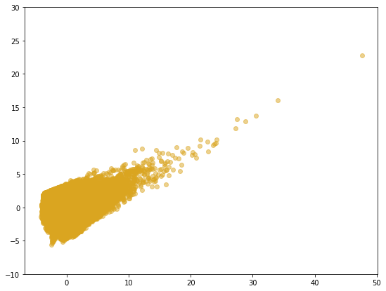

```python
# show the first two dim
plt.figure(figsize = (9,7))
plt.scatter(x3d[:,0],x3d[:,1], c='goldenrod',alpha=0.5)
plt.ylim(-10,30)
plt.show()
```

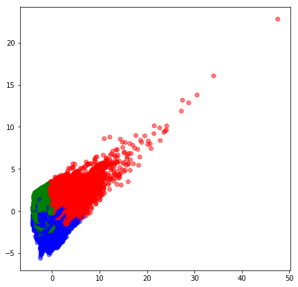

```python
# I use 3 clusters
kmeans = KMeans(n_clusters=3)
X_cluster = kmeans.fit_predict(x3d)

# set the color for label
label_color_hashmap = {0 : 'r',1 : 'g',2 : 'b'}
label_color = [label_color_hashmap[xc] for xc in X_cluster]

# show the first two dim and use color label
plt.figure(figsize = (7,7))
plt.scatter(x3d[:,0],x3d[:,1], c= label_color, alpha=0.5)
plt.show()
```

```python
# create a dataframe
df = pd.DataFrame(x3d)
df = df[[0, 1, 2]] # only want to visualise relationships between first 3 projections
df['X_cluster'] = X_cluster
```

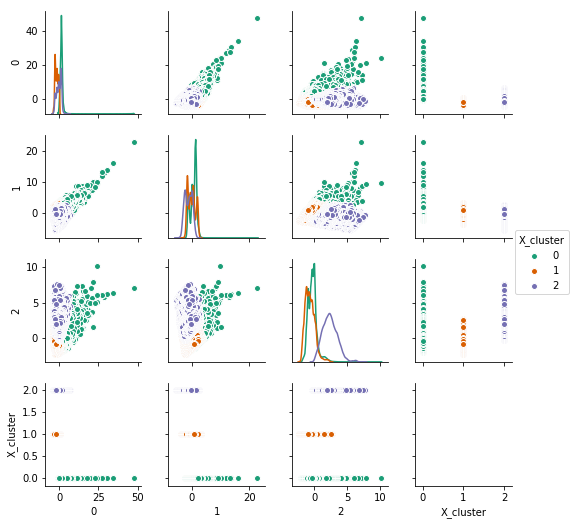

```python
sns.pairplot(df, hue='X_cluster', palette= 'Dark2', diag_kind='kde',size=1.85)
```

```python
df['X_cluster'].value_counts()
```

```
0    525558
1    508067
2    190492
Name: X_cluster, dtype: int64
```

```python
clusters_df_final.shape
```

```
(1224117, 13)
```

```python
# assign label to previous dataset
clusters_df_final = clusters_df_final.assign(X_cluster=df['X_cluster'].values)
clusters_df_final.head()
```

|  | Applicant_Income_000 | As_of_Year | Census_Tract_Number | County_Code | FFIEC_Median_Family_Income | Loan_Amount_000 | MSA_MD | Number_of_Owner_Occupied_Units | Sequence_Number | State_Code | Tract_to_MSA_MD_Income_Pct | Conforming_Limit_000 | Assets_000_Panel | X_cluster |
| --- | --- | --- | --- | --- | --- | --- | --- | --- | --- | --- | --- | --- | --- | --- |
| 0 | 84.0 | 2012 | 207.00 | 79.0 | 54900.0 | 94 | 16620.0 | 1545.0 | 390 | 54 | 93.07 | 417.0 | 793399 | 1 |
| 1 | 84.0 | 2012 | 9556.00 | 43.0 | 54900.0 | 133 | 16620.0 | 1548.0 | 422 | 54 | 58.00 | 417.0 | 793399 | 1 |
| 2 | 53.0 | 2012 | 9556.00 | 43.0 | 54900.0 | 70 | 16620.0 | 1548.0 | 425 | 54 | 58.00 | 417.0 | 793399 | 1 |
| 3 | 85.0 | 2012 | 206.01 | 79.0 | 54900.0 | 102 | 16620.0 | 1935.0 | 432 | 54 | 145.21 | 417.0 | 793399 | 1 |
| 4 | 38.0 | 2012 | 107.01 | 39.0 | 54900.0 | 112 | 16620.0 | 1492.0 | 478 | 54 | 127.96 | 417.0 | 793399 | 1 |

```python
svm_x, svm_y = np.split(clusters_df_final, (13,), axis=1)
```

```python
# split train and test datasets
svm_x_train, svm_x_test, svm_y_train, svm_y_test = train_test_split(svm_x, svm_y, random_state=1, train_size=0.7)
```

```python
# clf = svm.SVC(C=0.8, kernel='rbf', gamma=20, decision_function_shape='ovr')
clf = RandomForestClassifier(min_samples_leaf=20)
clf.fit(svm_x_train, svm_y_train)
```

```
RandomForestClassifier(bootstrap=True, class_weight=None, criterion='gini',
            max_depth=None, max_features='auto', max_leaf_nodes=None,
            min_impurity_decrease=0.0, min_impurity_split=None,
            min_samples_leaf=20, min_samples_split=2,
            min_weight_fraction_leaf=0.0, n_estimators=10, n_jobs=1,
            oob_score=False, random_state=None, verbose=0,
            warm_start=False)
```

```python
# accuracy
clf.score(svm_x_test, svm_y_test)
```

```
0.9893093269723012
```

# Conculation: Change Financial can focus on purchase propose, normal amount loan (0 - 347000), and conventional/conforming (less risk) in the VA and MD area.

## Reason 4: Around 70% market share for loan is under companies whose are less than 2% market share.

## Reason 5: The amout of loan for conventional/conforming is same as non-conventional/conforming but conventional/conforming has less risk.